# 11. Power Analysis

Jasper Slingsby

## Power Analysis

No one ever does them…

…but they could save so much pain and suffering if they did!!!

## Power Analysis

*Statistical power* is the probability of a hypothesis test finding an effect if there is an effect to be found.

*Power analysis* is a calculation typically used to estimate the smallest sample size needed for an experiment, given a required significance level, statistical power, and effect size.

- It is *normally conducted before the data collection*.

## Why do power analysis?

Not knowing the statistical power of your analysis can result in

- missed findings (through Type II Error), or
- false findings (through Type I Error).

## Why do power analysis?

Type II Error:

- occurs when the researcher erroneously concludes that there is *not* a difference between treatments, when in reality there is…
- this is a common outcome of low statistical power

## Why do power analysis?

Type I Error:

- occurs when the researcher erroneously concludes that there *is* a difference between treatments, when in reality there is not…
- less likely when there is poor statistical power, but can happen if there with low sample sizes of highly variable subjects, or if there is bias in sampling…

## Why do power analysis?

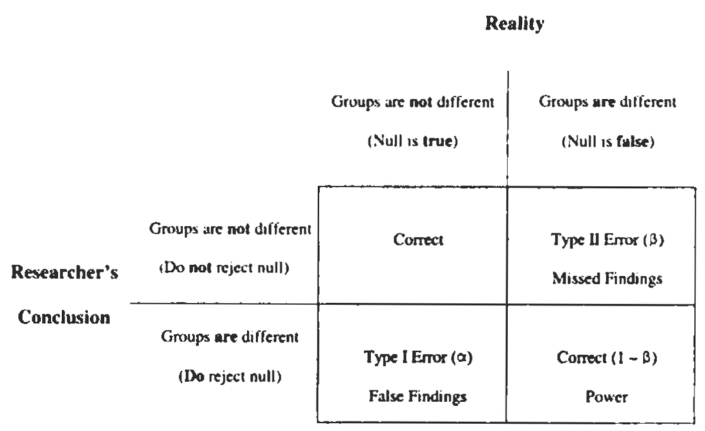

Type I and Type II Errors and how they result in false or missing findings, respectively. Image from Norton and Strube 2001, *JOSPT*.

## Statistical Power

Is determined by the combination of the:

- $\alpha$ (“significance”) level required (e.g. P < 0.05)
- difference between group means
- variability among subjects
- sample size (the factor we usually have most control over)

## $\alpha$ (“significance”) level

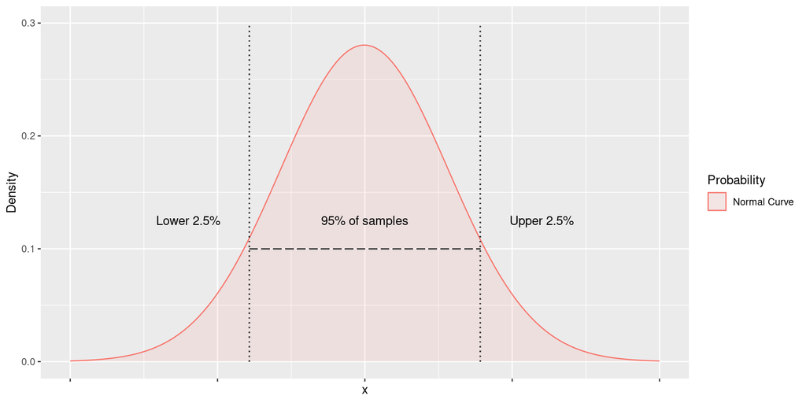

We usually use an $\alpha$ of 0.05 to indicate significant difference.

- i.e. the probability of the observation not being different to the null is less than 5% (i.e. p < 0.05), or the result should only be observed once or less for every 20 samples.

This is a subjective cut-off, but is generally accepted in the literature…

## Difference between group means

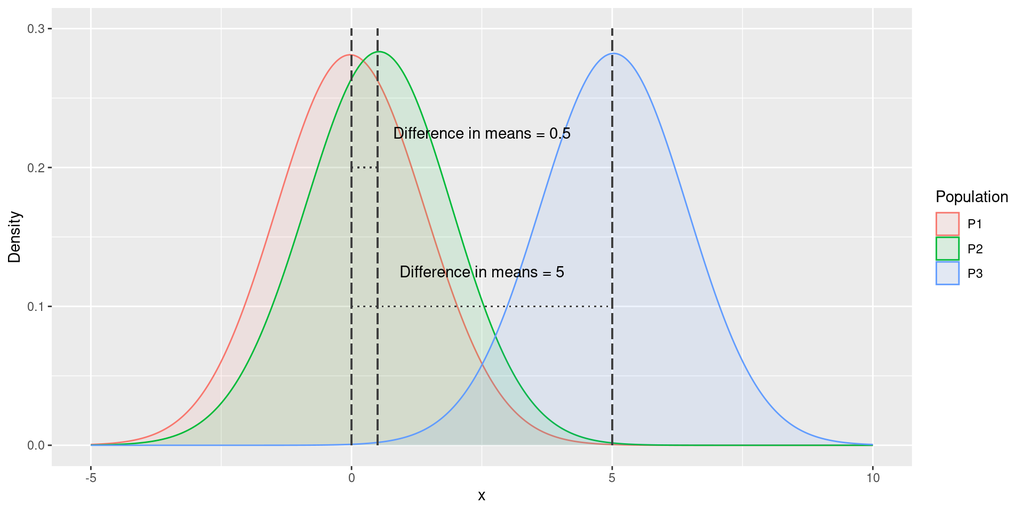

## Code

[output not shown]